# Tree-Based Methods

Author

Daniel Redel

# ISLR: Classification Trees

We first use classification trees to analyze the `Carseats` data set. In these data, `Sales` is a continuous variable, and so we begin by recoding it as a binary variable:

- We create a new variable `High` to denote if `Sales <= 8`, then the `Sales` predictor is removed as it is a perfect predictor of `High`.

```r
carseats <- ISLR::Carseats %>%
  as_tibble() %>%
  mutate(High = factor(ifelse(Sales <= 8, "No", "Yes")))
```

## Summary Statistics

Table 1: Carseats Dataset

| Sales | CompPrice | Income | Advertising | Population | Price | ShelveLoc | Age | Education | Urban | US | High |
| --- | --- | --- | --- | --- | --- | --- | --- | --- | --- | --- | --- |
| 9.50 | 138 | 73 | 11 | 276 | 120 | Bad | 42 | 17 | Yes | Yes | Yes |
| 11.22 | 111 | 48 | 16 | 260 | 83 | Good | 65 | 10 | Yes | Yes | Yes |
| 10.06 | 113 | 35 | 10 | 269 | 80 | Medium | 59 | 12 | Yes | Yes | Yes |
| 7.40 | 117 | 100 | 4 | 466 | 97 | Medium | 55 | 14 | Yes | Yes | No |
| 4.15 | 141 | 64 | 3 | 340 | 128 | Bad | 38 | 13 | Yes | No | No |
| 10.81 | 124 | 113 | 13 | 501 | 72 | Bad | 78 | 16 | No | Yes | Yes |

```r
carseats %>%
  tbl_summary(statistic = list(
    all_continuous() ~ "{mean} ({sd})"),
    digits = all_continuous() ~ 3)
```

Table 2: Summary Statistics

| **Characteristic** | **N = 400**<sup>1</sup> |
| --- | --- |
| Sales | 7.496 (2.824) |
| CompPrice | 124.975 (15.335) |
| Income | 68.658 (27.986) |
| Advertising | 6.635 (6.650) |
| Population | 264.840 (147.376) |
| Price | 115.795 (23.677) |
| ShelveLoc |  |
| Bad | 96 (24%) |
| Good | 85 (21%) |
| Medium | 219 (55%) |
| Age | 53.323 (16.200) |
| Education |  |
| 10 | 48 (12%) |
| 11 | 48 (12%) |
| 12 | 49 (12%) |
| 13 | 43 (11%) |
| 14 | 40 (10%) |
| 15 | 36 (9.0%) |
| 16 | 47 (12%) |
| 17 | 49 (12%) |
| 18 | 40 (10%) |
| Urban | 282 (71%) |
| US | 258 (65%) |
| High | 164 (41%) |

<sup>1</sup> Mean (SD); n (%)

## Classification Trees

Now we try to predict `High` using all variables but `Sales`.

```r
tree_carseats <- tree(High ~ . - Sales, data = carseats)
summary(tree_carseats)
```

```
Classification tree:
tree(formula = High ~ . - Sales, data = carseats)
Variables actually used in tree construction:
[1] "ShelveLoc"   "Price"       "Income"      "CompPrice"   "Population"
[6] "Advertising" "Age"         "US"
Number of terminal nodes:  27
Residual mean deviance:  0.4575 = 170.7 / 373
Misclassification error rate: 0.09 = 36 / 400
```

The `summary()` function lists the variables that are used as internal nodes in the tree, the number of terminal nodes, and the (training) error rate. We see that the **training error rate is 9%**.

But we will actually use the `rpart` package for trees.

The `rpart` function has some default parameters that prevented our tree from growing. Namely `minsplit` and `minbucket`.

- `minsplit` is *"the minimum number of observations that must exist in a node in order for a split to be attempted"*;
- `minbucket` is *"the minimum number of observations in any terminal node"*.

```r
tree_carseats <- rpart(High ~ . - Sales,
                       data = carseats,
                       method = "class")
```

The `rpart.plot` package provides functions to let us easily visualize the decision tree. As the name implies, it only works with `rpart` trees.

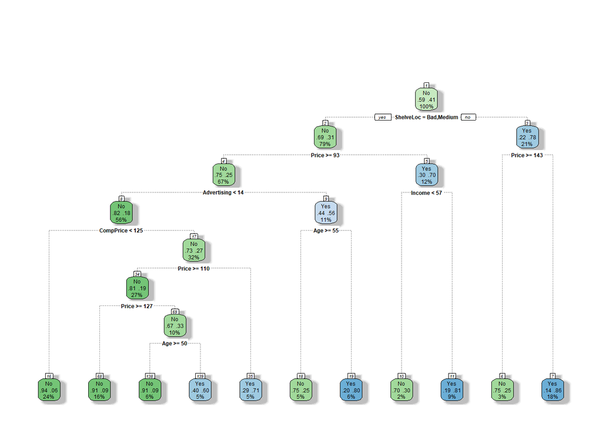

Figure 1: Decision Tree of Sales

```r
fancyRpartPlot(tree_carseats, caption = NULL)
```

We can see that the most important variable to predict high sales appears to be shelving location (`ShelveLoc`) as it forms the first node. But if we actualy report the Variable Importance, we will see that `Price` is the most important variable here:

```r
data.frame(vi=tree_carseats$variable.importance) %>%
  kbl() %>%
  kable_styling(bootstrap_options = c("striped", "hover", "condensed"))
```

Table 3: Variable Importance

|  | vi |
| --- | --- |
| Price | 39.3458304 |
| ShelveLoc | 28.9918954 |
| Age | 13.0761815 |
| Advertising | 12.7110483 |
| CompPrice | 10.2253806 |
| Income | 6.2611750 |
| Population | 3.1669718 |
| Education | 0.9670985 |
| US | 0.1411614 |

### Performance Assessment

In order to properly evaluate the performance of a classification tree on these data, we must estimate the test error rather than simply computing the training error.

```r
set.seed(345)
index <- sample(1:nrow(carseats), 0.7*nrow(carseats))

train <- carseats[index,] # Create the training data
test <- carseats[-index,] # Create the test data

dim(train)
```

```
[1] 280  12
```

```r
dim(test)
```

```
[1] 120  12
```

We can build a **confusion matrix** to assess prediction accuracy on our **test data**:

```r
tree_carseats <- rpart(High ~ . - Sales,
                       data = train,
                       method = "class")

tree.pred <- predict (tree_carseats, newdata = test, type = "class")
cm <- confusionMatrix(factor(tree.pred), test$High)
cm
```

```
Confusion Matrix and Statistics

          Reference
Prediction No Yes
       No  51  13
       Yes 22  34

               Accuracy : 0.7083
                 95% CI : (0.6184, 0.7877)
    No Information Rate : 0.6083
    P-Value [Acc > NIR] : 0.01454

                  Kappa : 0.4081

 Mcnemar's Test P-Value : 0.17630

            Sensitivity : 0.6986
            Specificity : 0.7234
         Pos Pred Value : 0.7969
         Neg Pred Value : 0.6071
             Prevalence : 0.6083
         Detection Rate : 0.4250
   Detection Prevalence : 0.5333
      Balanced Accuracy : 0.7110

       'Positive' Class : No
```

We have an **Accuracy of 70.83%**.

A more visual representation of the confusion matrix can be done by generating a `ggplot2` chart:

```r
plt <- as.data.frame(cm$table)

plotTable <- plt %>%
  mutate(Correct = ifelse(plt$Prediction == plt$Reference, "TRUE", "FALSE")) %>%
  group_by(Reference) %>%
  mutate(prop = Freq/sum(Freq))
```

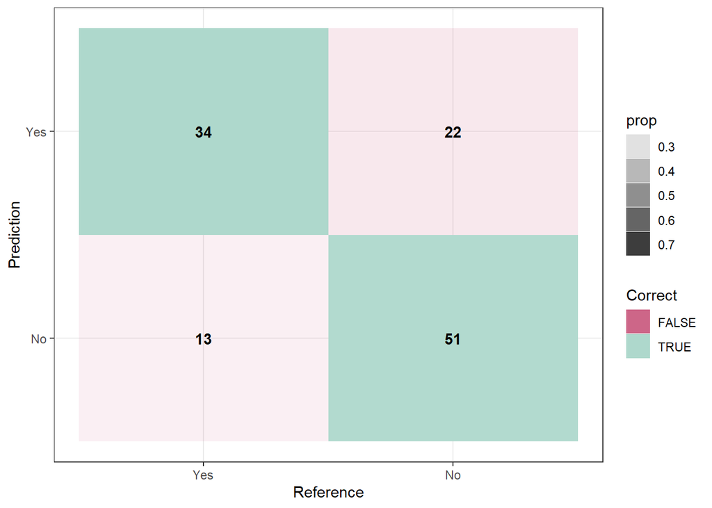

Figure 2: Confusion Matrix: Decision Tree

```r
ggplot(plotTable, aes(x = Reference, y = Prediction, fill = Correct, alpha = prop)) +
  geom_tile() +
  geom_text(aes(label = Freq), vjust = .5, fontface  = "bold", alpha = 1) +
  scale_fill_manual(values = c("TRUE" = "#AED8CC", "FALSE" = "#CD6688")) +
  theme_bw() +
  xlim(rev(levels(plt$Reference)))
```

### Pruning the Tree

Next, we consider whether pruning the tree might lead to improved results.

- The `printcp` and `plotcp` functions provide the cross-validation error for each `nsplit` and can be used to prune the tree.
- The one with *least cross-validated error (`xerror`) is the optimal value of CP* given by the `printcp()` function.
- By default, `rpart` is performing some automated tuning.

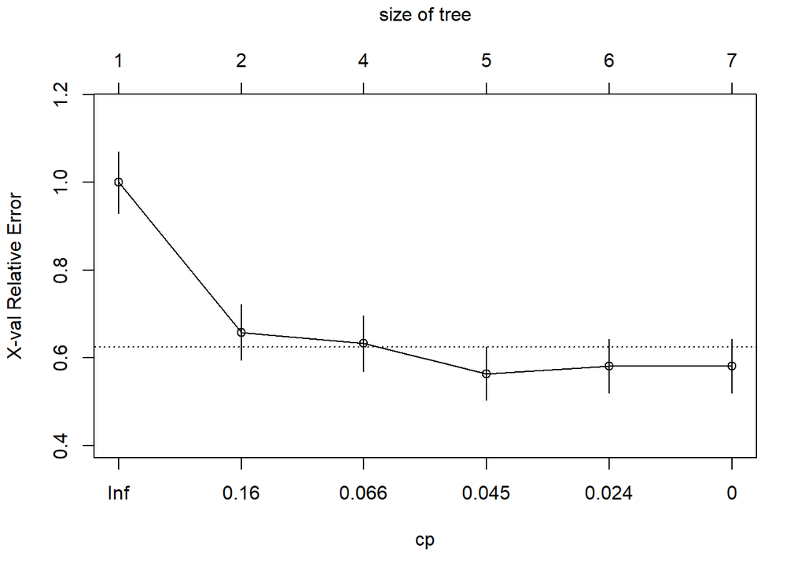

```r
set.seed(345)
tree_carseats <- rpart(High ~ . - Sales,
                       data = train,
                       method = "class",
                       cp = 0)
plotcp(tree_carseats)
```

```r
data.frame(tree_carseats$cptable) %>%
  kbl() %>%
  kable_styling(bootstrap_options = c("striped", "hover", "condensed"))
```

Table 4: Cost-Complexity

| CP | nsplit | rel.error | xerror | xstd |
| --- | --- | --- | --- | --- |
| 0.3418803 | 0 | 1.0000000 | 1.0000000 | 0.0705378 |
| 0.0726496 | 1 | 0.6581197 | 0.6581197 | 0.0638599 |
| 0.0598291 | 3 | 0.5128205 | 0.6324786 | 0.0630644 |
| 0.0341880 | 4 | 0.4529915 | 0.5641026 | 0.0607035 |
| 0.0170940 | 5 | 0.4188034 | 0.5811966 | 0.0613278 |
| 0.0000000 | 6 | 0.4017094 | 0.5811966 | 0.0613278 |

The model with the lowest `xerror`:

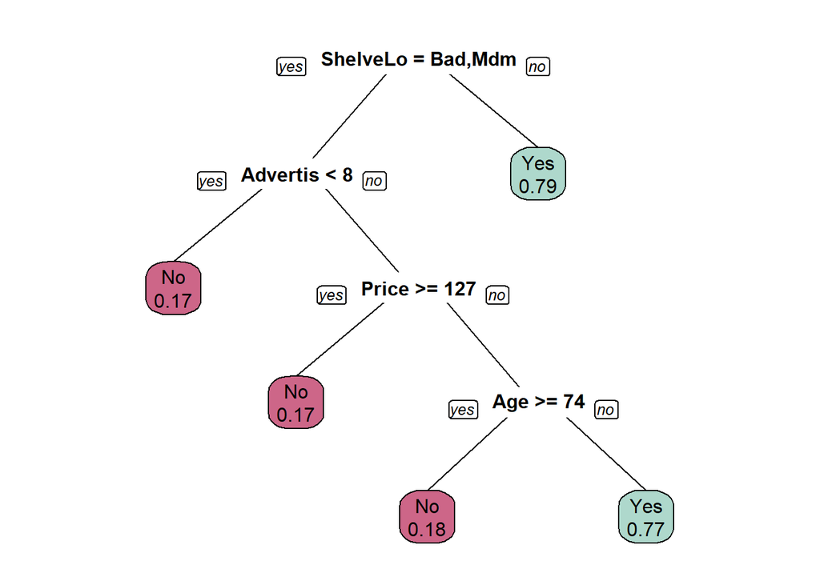

Figure 3: Prunned Classification Tree

```r
ptree <- prune(tree_carseats,
              cp = tree_carseats$cptable[which.min(tree_carseats$cptable[,"xerror"]),"CP"])

prp(ptree, yesno = 2, extra = 6, box.palette=c("#CD6688", "#AED8CC")) # or extra=4
```

```r
tree.pred <- predict (ptree, newdata = test, type = "class")
cm <- confusionMatrix(factor(tree.pred), test$High)
cm$overall[1]
```

```
Accuracy
     0.7
```

- Note that we use `prp` function to customize our tree visualization.

# ISLR: Regression Trees

Here we fit a regression tree to the `Boston` data set. First, we create a training set, and fit the tree to the training data:

```r
set.seed(345)

index <- sample(1:nrow(Boston), 0.7*nrow(Boston))

boston_train <- Boston[index,] # Create the training data
boston_test <- Boston[-index,] # Create the test data
```

Fitting the model to the training data set:

```r
set.seed(345)
tree_boston <- rpart(medv ~.,
                       data = boston_train,
                       method = "anova") ## for regression trees
```

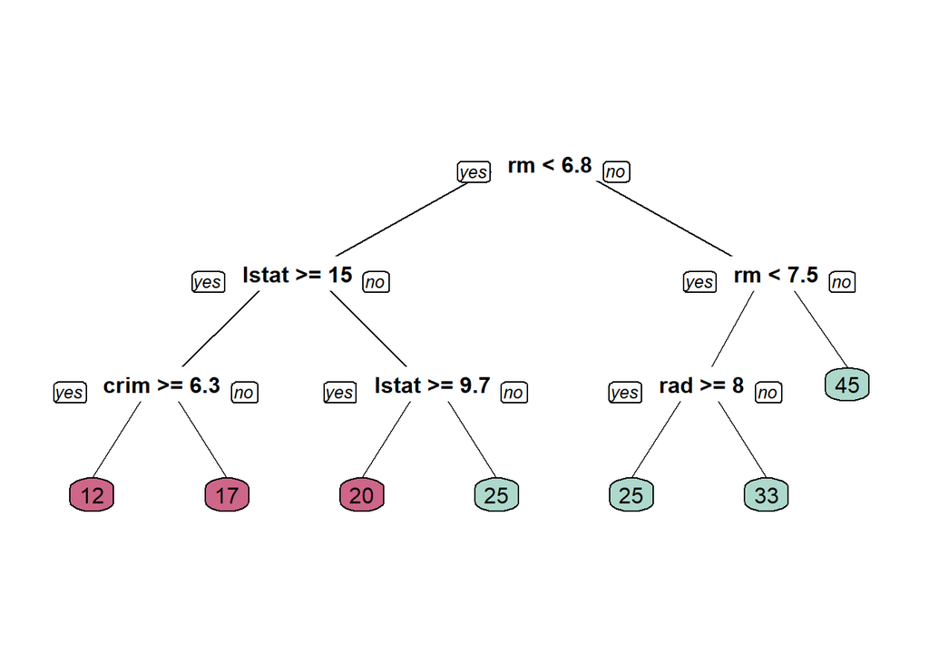

Figure 4: Regression Tree of Home Value

```r
prp(tree_boston,yesno = 2, box.palette=c("#CD6688", "#AED8CC"))
```

### Performance Assessment

To evaluate predicting performance in regression trees, we will use the **MSE/RMSE metrics**:

```r
eval_results <- function(true, predicted, df) {
  SSE <- sum((predicted - true)^2)
  MSE <- SSE/nrow(df)                            # Mean-Squared Error
  RMSE = sqrt(SSE/nrow(df))                      # Root Mean-Squared Error

  # Model performance metrics
data.frame(
  MSE = MSE,
  RMSE = RMSE
)

}
```

```r
tree.pred <- predict(tree_boston, newdata = boston_test) ## no "class" type

eval_results(boston_test$medv, tree.pred, boston_test) %>%
  kbl() %>%
  kable_styling(bootstrap_options = c("striped", "hover", "condensed"))
```

Table 5: Model Performance: Regression Tree

| MSE | RMSE |
| --- | --- |
| 33.37421 | 5.777041 |

### Pruning the Tree

Let’s consider the full tree:

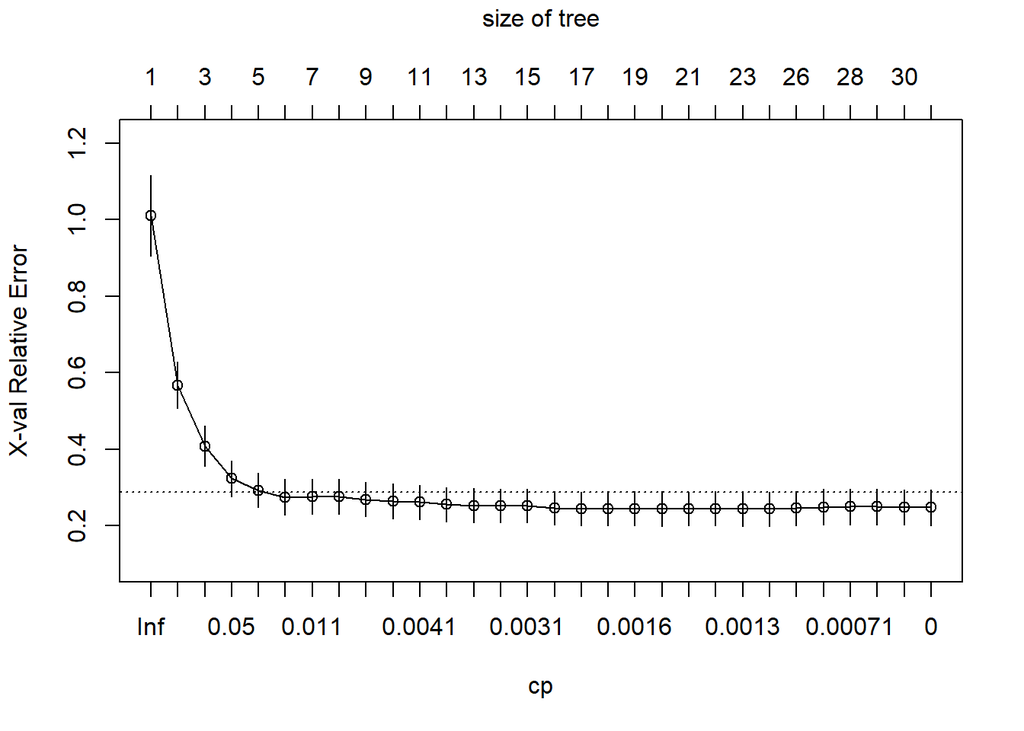

```r
set.seed(345)
tree_boston <- rpart(medv ~.,
                       data = boston_train,
                       method = "anova", cp = 0.00)
plotcp(tree_boston)
```

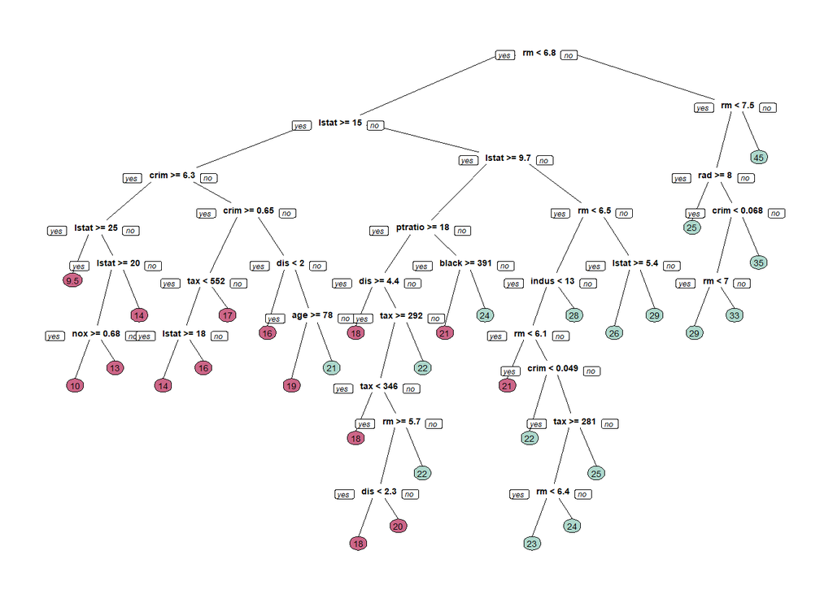

Figure 5: Full Regression Tree

```r
tree.pred <- predict(tree_boston, newdata = boston_test) ## no "class" type

eval_results(boston_test$medv, tree.pred, boston_test) %>%
  kbl() %>%
  kable_styling(bootstrap_options = c("striped", "hover", "condensed"))
```

Table 6: Model Performance: Full Regression Tree

| MSE | RMSE |
| --- | --- |
| 27.48546 | 5.242658 |

The model with the lowest `xerror`:

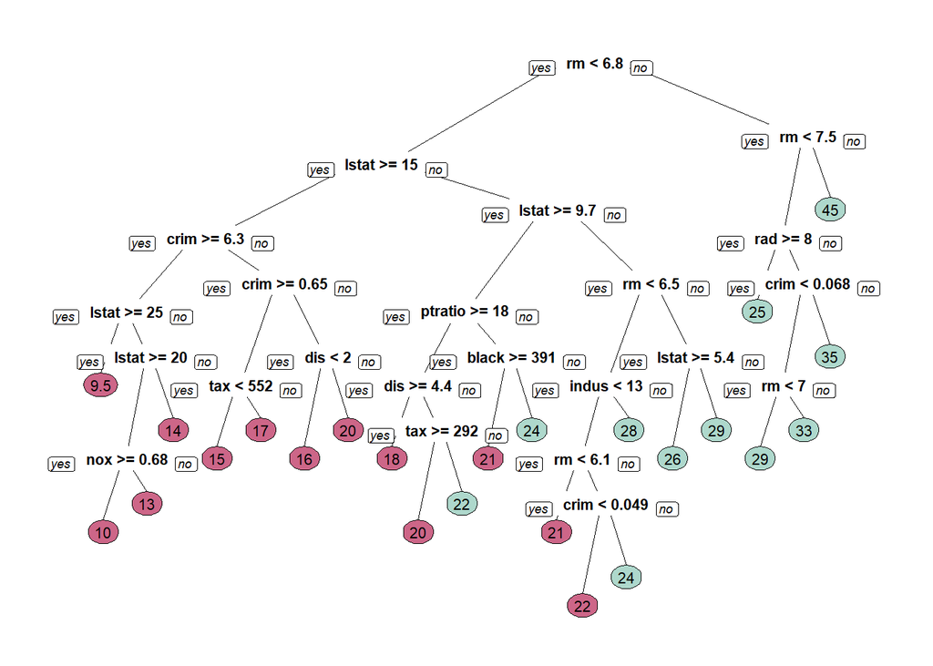

Figure 6: Prunned Regression Tree

```r
ptree <- prune(tree_boston,
              cp = tree_boston$cptable[which.min(tree_boston$cptable[,"xerror"]),"CP"])

prp(ptree, yesno = 2, box.palette=c("#CD6688", "#AED8CC")) # or extra=4
```

Let’s get our *MSE/RMSE* metrics:

```r
tree.pred <- predict (ptree, boston_test) ## no "class" type

eval_results(boston_test$medv, tree.pred, boston_test) %>%
  kbl() %>%
  kable_styling(bootstrap_options = c("striped", "hover", "condensed"))
```

Table 7: Model Performance: Pruned Regression Tree

| MSE | RMSE |
| --- | --- |
| 27.55519 | 5.249303 |

## Bagging & Random Forests

Here we apply bagging and random forests to the `Boston` data set. We will be using the `randomForest` package as the engine.

- A bagging model is a special case of a random forest with $m=p$ where `mtry` is equal to the number of predictors.
- We can specify the `mtry` to be `ncol()-1` which means that the number of columns in the predictor matrix is used (removing the dependent variable).

### Bagging

Let’s start with our bagging model. In bagging, we are using all the predictors available for each split.

```r
set.seed(345)
bag_boston <- randomForest(medv ~ ., data = boston_train,
                           mtry = ncol(boston_train)-1, importance = TRUE)
bag_boston
```

```
Call:
 randomForest(formula = medv ~ ., data = boston_train, mtry = ncol(boston_train) -      1, importance = TRUE)
               Type of random forest: regression
                     Number of trees: 500
No. of variables tried at each split: 13

          Mean of squared residuals: 12.39109
                    % Var explained: 83.76
```

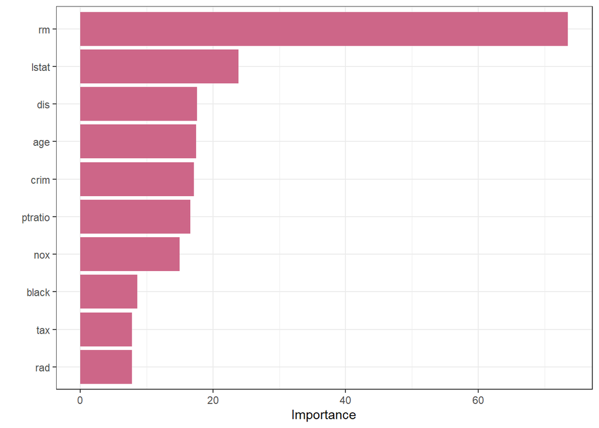

Figure 7: Variable Importance

```r
vip(bag_boston, aesthetics = list(fill = "#CD6688")) + theme_bw()
```

```r
bag.pred <- predict(bag_boston, newdata = boston_test)

eval_results(boston_test$medv, bag.pred, boston_test) %>%
  kbl() %>%
  kable_styling(bootstrap_options = c("striped", "hover", "condensed"))
```

Table 8: Model Performance: Bagging

| MSE | RMSE |
| --- | --- |
| 18.11275 | 4.255907 |

The test MSE is much lower using bagging than using a single decision tree. Let's see if the test error further decreases when using random forest instead.

### Random Forest

Next, let us take a look at a Random Forest.

- By default, `randomForest()` uses `p/3` variables when building a random forest **for regression trees**, and `sqrt(p)` variables when building a random forest **for classification trees**.
- Here we use `mtry = 6`.

```r
set.seed(345)
rf_boston <- randomForest(medv ~ ., data = boston_train,
                           mtry = 6, importance = TRUE)
rf_boston
```

```
Call:
 randomForest(formula = medv ~ ., data = boston_train, mtry = 6,      importance = TRUE)
               Type of random forest: regression
                     Number of trees: 500
No. of variables tried at each split: 6

          Mean of squared residuals: 10.91157
                    % Var explained: 85.7
```

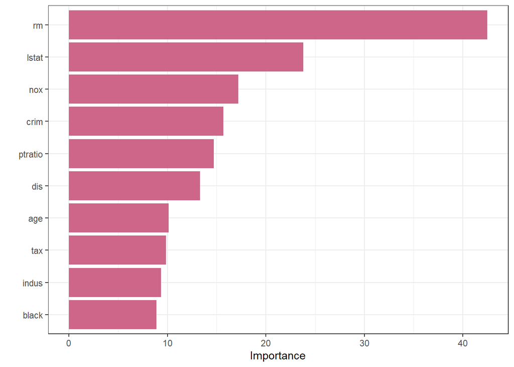

Figure 8: Variable Importance

```r
vip(rf_boston, aesthetics = list(fill = "#CD6688")) + theme_bw()
```

```r
rf.pred <- predict(rf_boston, newdata = boston_test)

eval_results(boston_test$medv, rf.pred, boston_test) %>%
  kbl() %>%
  kable_styling(bootstrap_options = c("striped", "hover", "condensed"))
```

Table 9: Model Performance: Random Forest

| MSE | RMSE |
| --- | --- |
| 16.69036 | 4.085384 |

## Boosting

We will now fit a boosted tree model.

- To fit boosted regression trees we need to specify `distribution = "gaussian"`.
- To use classification trees instead, we use `distribution = "bernoulli`

We set `n.tree` `= 5000` to grow 5000 trees with a maximal depth of 4:

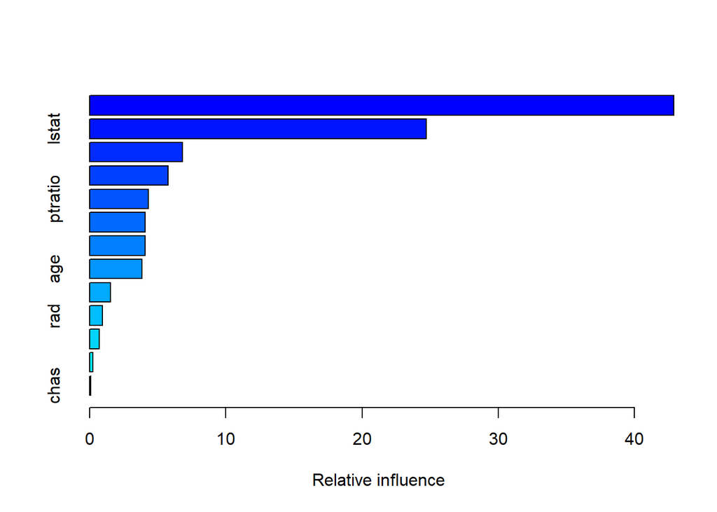

```
            var     rel.inf
rm           rm 42.88339199
lstat     lstat 24.71055094
dis         dis  6.80641563
crim       crim  5.75903125
ptratio ptratio  4.33128086
black     black  4.09087730
nox         nox  4.06061420
age         age  3.83636955
tax         tax  1.53100288
rad         rad  0.95943008
indus     indus  0.70584492
zn           zn  0.22531868
chas       chas  0.09987172
```

```r
set.seed(345)
boost_boston <- gbm(medv ~ .,
                    data = boston_train,
                    distribution = "gaussian",
                    n.trees = 5000,
                    interaction.depth = 4)

summary(boost_boston)
```

```r
pred_boost <- predict(boost_boston, new_data = boston_test)

eval_results(boston_test$medv, pred_boost, boston_test) %>%
  kbl() %>%
  kable_styling(bootstrap_options = c("striped", "hover", "condensed"))
```

Table 10: Model Performance: Boosting

| MSE | RMSE |
| --- | --- |
| 411.5822 | 20.28749 |